# Data Science Capstone Project Milestone Report

October 16, 2017

## Summary

This report will go over the download of the project dataset, along with reading the dataset into R. It will then look at some general file information for the dataset files. The dataset will then be sampled to create a subset of the source dataset to be cleaned and used for exploratory analysis.

## Setup

1. The required libraries for this analysis are:
   - ggplot2
   - Rweka
   - SnowballC
   - stringi
2. The homedir parameter is the current working directory

## Download Dataset

Download project dataset from weblink provided in course instructions

```r
url <- "https://d396qusza40orc.cloudfront.net/dsscapstone/dataset/Coursera-SwiftKey.zip"
filename <- "swiftkey.zip"
download.file(url, destfile = filename)
unzip(filename, exdir = homedir)
```

## Source Dataset

### Read and Summarize Dataset

- Read the source dataset text files (blogs, news and twitter) into R for further examination.
- Provide some general summary information on the files from the source dataset to get an idea of size and amount of data included. This includes file size, number of lines of text, and the length of the longest line of text for each of the dataset files.

```r
srcdir <- paste(homedir, "/swiftkey/final/en_US", sep = "")
blogfile <- paste(srcdir, "/en_US.blogs.txt", sep = "")
newsfile <- paste(srcdir, "/en_US.news.txt", sep = "")
twitterfile <- paste(srcdir, "/en_US.twitter.txt", sep = "")

con <- file(blogfile, "r")
blogs <- readLines(con, skipNul = TRUE)
close(con)

con <- file(newsfile, "r")
news <- readLines(con, skipNul = TRUE)
close(con)

con <- file(twitterfile, "r")
twitter <- readLines(con, skipNul = TRUE)
close(con)
```

```
##         filesize textlines longestline
## blog    200.4242    899288       40835
## news    196.2775     77259        5760
## twitter 159.3641   2360148         213
```

## Preprocess Dataset

Due to the size of the dataset files, particularly the blog and twitter files a sample of each of the dataset files is taken in order to reduce run times when performing analysis on the dataset. This random sample of the full dataset should still yield an accurate approximation to the results that would be obtained from using the full dataset. The sample sizes for each file are:

- blog – 2%
- news – 25%
- twitter – 1%

A summary of the counts of sample lines of text taken from the individual files, as well as the total number of sample lines taken from the dataset is below.

```r
set.seed(314)

corpdir <- paste(homedir, "/corpora", sep = "")

blogs_sample <- sample(blogs,length(blogs)*0.02)
#0.055
news_sample <- sample(news,length(news)*0.25)
#0.64
twitter_sample <- sample(twitter,length(twitter)*0.01)
#0.021

samcorpus <- c(blogs_sample, news_sample, twitter_sample)
samcorpus <- sapply(samcorpus, function(row) iconv(row, "latin1", "ASCII", sub = ""))

corpusfile <- paste(corpdir, "/sampletext.txt", sep = "")
con <- file(corpusfile, "wt")
writeLines(samcorpus, con)
close(con)

samplines <- as.matrix(c(length(blogs_sample), length(news_sample), length(twitter_sample),
                          sum(length(blogs_sample), length(news_sample), length(twitter_sample))))
rownames(samplines)<-c("blogs", "news", "twitter", "total")
colnames(samplines)<-c("TextLines")
print(samplines)
```

```
##         TextLines
## blogs       17985
## news        19314
## twitter     23601
## total       60900
```

## Clean Data

Utilizing the “tm” package the sample dataset is now cleaned by performing the following tasks:

1. Removing unnecessary whitespace
2. Transform all text to lower case
3. Remove numbers
4. Remove punctuations
5. Remove stopwords (words that are so common that their information value is negligible)
6. Remove profanity (the list of words in this category was derived from a source list found [here](https://www.cs.cmu.edu/~biglou/resources/bad-words.txt))
7. More specific profanity removal related to the two most common profane terms

The cleaned sample dataset is then written to a separate text file that may be referenced for further analysis.

```r
profanityfile <- paste(homedir, "/profanity.txt", sep = "")

con <- file(profanityfile, "r")
profanity <- readLines(con, skipNul = TRUE)
close(con)

usource <- URISource(corpusfile, encoding = "UTF-8", "text")
(samcorp <- VCorpus(usource, readerControl = list(language = "en")))

samcorp <- tm_map(samcorp, stripWhitespace)
samcorp <- tm_map(samcorp, content_transformer(tolower))
samcorp <- tm_map(samcorp, removeNumbers)
samcorp <- tm_map(samcorp, removePunctuation)
samcorp <- tm_map(samcorp, removeWords, stopwords("english"))
samcorp <- tm_map(samcorp, removeWords, profanity)
samcorp <- tm_map(samcorp, content_transformer(function(x) gsub("\\S+shit\\S+", "", x)))
samcorp <- tm_map(samcorp, content_transformer(function(x) gsub("\\S+shit", "", x)))
samcorp <- tm_map(samcorp, content_transformer(function(x) gsub("shit\\S+", "", x)))
samcorp <- tm_map(samcorp, content_transformer(function(x) gsub("\\S+fuck\\S+", "", x)))
samcorp <- tm_map(samcorp, content_transformer(function(x) gsub("\\S+fuck", "", x)))
samcorp <- tm_map(samcorp, content_transformer(function(x) gsub("fuck\\S+", "", x)))

writeCorpus(samcorp, path = corpdir, filenames = "sampletext_clean.txt")
```

## Exploratory Analysis

The cleaned sample dataset is analyzed for unigram, bigram and trigram term (the appearance of 1 term, 2 terms and 3 terms together in a row, respectively) frequencies

```r
gram1 <- function(n) NGramTokenizer(n, Weka_control(min = 1, max = 1))
gram2 <- function(n) NGramTokenizer(n, Weka_control(min = 2, max = 2))
gram3 <- function(n) NGramTokenizer(n, Weka_control(min = 3, max = 3))

samtdm1 <- TermDocumentMatrix(samcorp, control = list(tokenize = gram1))
samtdm2 <- TermDocumentMatrix(samcorp, control = list(tokenize = gram2))
samtdm3 <- TermDocumentMatrix(samcorp, control = list(tokenize = gram3))
```

### Unigram Term Frequencies

Below is a bar plot showing the top 50 unigram terms found in the dataset.

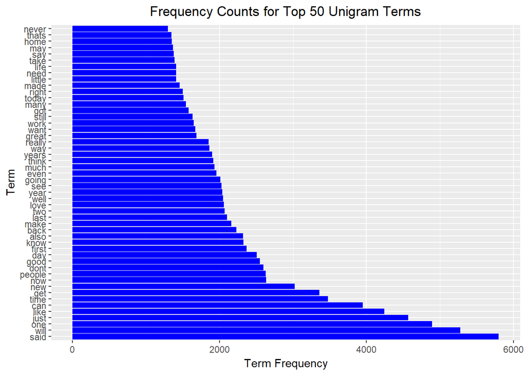

### Bigram Term Frequencies

Below is a bar plot showing the top 50 bigram terms found in the dataset.

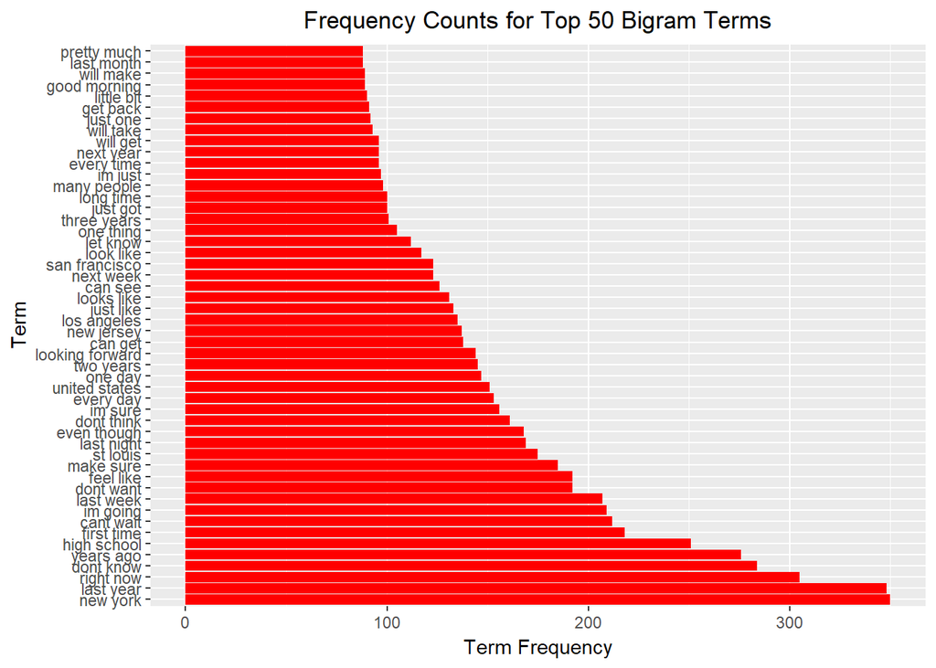

### Trigram Term Frequencies

Below is a bar plot showing the top 50 trigram terms found in the dataset.

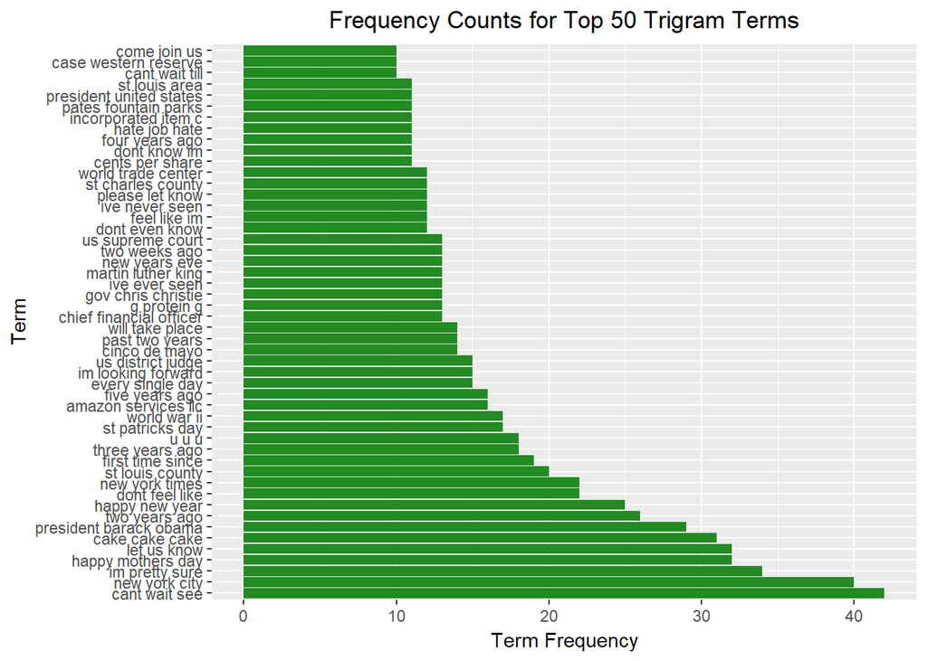

## Observations

1. A number of the most common trigram terms (and to a lesser extent bigram terms) are proper nouns or holiday related (specifically holiday names or congratulatory phrases).
2. Some terms and their pluralizations both appear (e.g. year and years, or look like and looks like).
3. Frequency counts in all 3 plots show a similar pattern. There is a sharp decrease in approximately the first 10 terms before frequency counts begin to decrease more gradually in more of a step pattern.

## Next Steps

1. Using the n-grams created from the sample dataset build a basic n-gram model to predict the next word in a sequence.
2. Translate the prediction model into a shiny app that will accept a phrase as input and use the model to predict the next word in the sequence.